# Corpus selection and online data collection

Malo Jan & Luis Sattelmayer

2026-01-19

# Corpus selection

## What is a corpus ?

- Every project involving text/image/videos analysis starts with a corpus
- A collection of *machine readable* texts/images/videos, along with metadata
- Corpus selection is a crucial task and often overlooked
- Corpus selection is sampling : identifying the population of interest
- Corpus selection is case selection : choosing documents to analyze according to research questions and interests
- What would be a corpus that would help me answer my research question ?
  - E.g.: Twitter data is fun but not useful for everything

## Corpus selection and bias

- Several aspects to consider when selecting a corpus
- How exhaustive is the corpus ?
  - Can I obtain the entirety of a document type/collection?
- Think about data generation process
  - How were these documents produced?
  - How could this affect the corpus?
- Important to explore, read some of the documents
- Think about quantity of interest, what could you derive as a measure from those documents :
  - eg. How much a given topic is discussed in these texts
  - eg. How much a given sentiment is expressed in these texts

## Potentiel Biases in text selection

- **Resource Bias**
  - “texts often better reflect populations with more ressources to produce, record, and store documents” (Grimmer, Roberts, and Stewart 2022)
  - social groups are marginalized and invisible in all societies, thus also in text
- **Incentive Bias**
  - (self-)censoring on Social Media or in official government documents is an issue (King, Pan, and Roberts 2013)
- **Medium Bias**
  - Twitter only allowed 140 characters until 2017 or meeting transcripts/speeches do not necessarily reflect the tonality of the actual communication
- **Retrieval Bias**
  - errors or skewed queries in text mining, intransparent APIs

## Acquiring a corpus

- Existing corpora vs creating original corpora
- Existing corpora
  - Texts available in open data : eg. [French parliament speeches](https://data.assemblee-nationale.fr/travaux-parlementaires/debats)
  - Texts released by other researchers : eg. [Manifesto corpus](https://manifesto-project.wzb.eu/information/documents/corpus), [UNGA corpus](https://dataverse.harvard.edu/dataset.xhtml?persistentId=doi:10.7910/DVN/0TJX8Y), [Parlspeech](https://dataverse.harvard.edu/dataset.xhtml?persistentId=doi:10.7910/DVN/L4OAKN), [EU commissioners press releases](https://dataverse.harvard.edu/dataset.xhtml?persistentId=doi:10.7910/DVN/UGGXUF), SOTU corpus
- Collecting digital texts
  - Image to text : digitization of images through Optical Character Recognition (OCR)
  - Audio/video to text : automatic transcription
  - Application programming interface (API)
  - Web scraping

# Transforming videos, audios and images into text

## Transcribing audio and video files

- A lot of data is in audio/video format such as interviews, radio shows, speeches, podcasts, etc.
- This data can be analyzed with text analysis tools through transcription
- Potential pipeline : download videos from youtube and transcribe audio with whisper

## Corpus creation with digitized texts

- Important avenues for research in the digital humanities
- Digitization of old texts, newspapers, books, archives
- Allows to create large original corpora
- Requires OCR (Optical Character Recognition) tools
  - Transforms images of texts into machine-readable text
  - Tools such as [Tesseract](https://cran.r-project.org/web/packages/tesseract/vignettes/intro.html), [TrOCR](https://huggingface.co/docs/transformers/model_doc/trocr)

# APIs

## Application programming interface (API)

- A common way to access and share data online
- Set of rules that allows one software application to communicate with another.
- Defines what requests can be made, how to make them, and the data formats to be used.

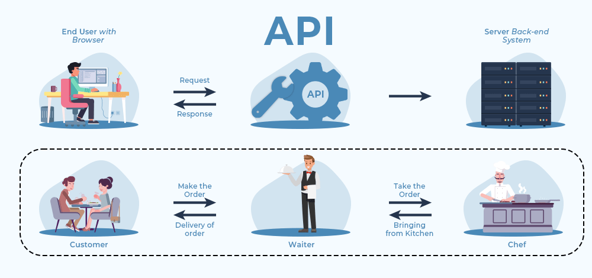

## APIS

- Accessing data usually involves :
  - Authenticating with an API key or token
  - Sending requests with specific parameters
  - Receiving structured data (e.g., JSON or XML)

## Advantages of APIS

- Allows for easy & legal access to data
- Get structured data that can be easily processed
- In many cases, someone has already created a package facilitating the access to the API : [NY Times](https://github.com/news-r/nytimes), [Manifesto project](https://manifesto-project.wzb.eu/information/documents/api), [Bluesky](https://github.com/JBGruber/atrrr), [Spotify](https://www.rcharlie.com/spotifyr/), [Youtube](https://developers.google.com/youtube/v3?hl=fr) [Twitter (RIP)](https://github.com/cjbarrie/academictwitteR)

## Limits of APIs

- Access only to the data that the API provider wants to share
- Often limited in the number of requests you can make
- Some APIs are not free : eg. Twitter API now
- APIcalypse/Post-API Age : APIs can be closed or modified at any time
  - Facebook, or Twitter that had before extensive API access for researchers but now closed (see minet for some workarounds)

## Learning how to use an API

- This course will not cover how to use APIs
- But there are many resources online, [here](https://tellingstorieswithdata.com/07-gather.html)
- Request data from API with [httr2](https://www.tidyverse.org/blog/2023/11/httr2-1-0-0/)
- Parse Json or XML in R with [jsonlite](https://cran.r-project.org/web/packages/jsonlite/vignettes/json-aaquickstart.html)

# Webscraping

## What is web scraping?

> Web scraping is a data collection technique on the web that involves extracting data from a web page.
- We are all manual web scrapers: copying/pasting/downloading data from the web daily.
- But we can automate all of this: machines are faster and more extensive than we are.

## Use cases

- Collecting social media data
- Collecting press releases from an organization, speeches from actors
- Extracting data from Wikipedia pages
- Automatically download hundreds of PDFs from a website
- Collect metadata from a website

## How the web is written

- Web scraping involves a minimum understanding of how the web is written: what is a web page?
  - Code: interpreted by a browser (ex: Chrome, Mozilla)
- The code of a web page can be written in:
  - HTML (**Hypertext markup language**): structure and content
  - CSS: style (ex: font, color)
  - Javascript: functionalities, dynamic content, search, drop-down menus etc.
- Exemple from the press release of the [UN Secretary General](https://press.un.org/en/content/secretary-general/press-release)

## HTML

- HTML is a markup language
- The content of the web is written in tags, which can have attributes

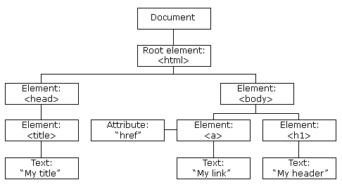

The tree-like structure of an HTML document

## HTML

- Most common tags in html
  - div
  - p
  - h1, h2, h3
- Web scraping consists in extracting the content of the html source code to get certain information
- CTRL + U/⌘-Option-U to see the source code of a web page
- [Selector Gadget](https://chromewebstore.google.com/detail/selectorgadget/mhjhnkcfbdhnjickkkdbjoemdmbfginb?hl=de&pli=1)

## Ethics on data access

- Web scraping is about collecting data not intended for you
  - May be illegal but also exceptions for research purposes
  - Access to private data, overload servers
  - Websites can block you/track you
- Good practices :
  - API first
  - Check permissions (robot.txt)
  - Slow down scraping

## Ethics on data use

- Web scraping can be used to collect personal and sensitive data
- E.g.: Old twitter API: possibility to download all tweets of a user in 2 lines of code
- Data protection laws (GDPR) apply to web scraping
- Need to think about the use of the data

[figure not shown]

## Complex and dynamic pages

- Web pages are sometimes complex and dynamic (javascript)
- More complex scraping strategies are needed
- Selenium: allows to simulate clicks on a browser from a script
- Web pages are also changed, updated: your program can work one day and not the next, good practice to download the hmtl pages on your computer

[figure not shown]

## References

Collecting online data

Grimmer, Justin, Margaret E Roberts, and Brandon M Stewart. 2022. *Text as Data: A New Framework for Machine Learning and the Social Sciences*. Princeton University Press.

King, Gary, Jennifer Pan, and Margaret E Roberts. 2013. “How Censorship in China Allows Government Criticism but Silences Collective Expression.” *American Political Science Review* 107 (2): 326–43.